# Predictors of Antidepressant Response and Side Effects in the Genetic Links to Anxiety and Depression (GLAD) Study

Analysis Report

Yuhao Lin

# Medication Clustering

**Create a matrix of receptor binding for antidepressants based on the binding constants from wikipedia and try to cluster them based on this; compare this with the table that you found in the paper.**

*From docs/dat_clean.md:*

> - The raw table is from this [web page](https://en.wikipedia.org/wiki/Pharmacology_of_antidepressants).
> - The “>” signs were discarded and all NA values were recoded to 0s.

## Visualisation with multidimensional scaling plot

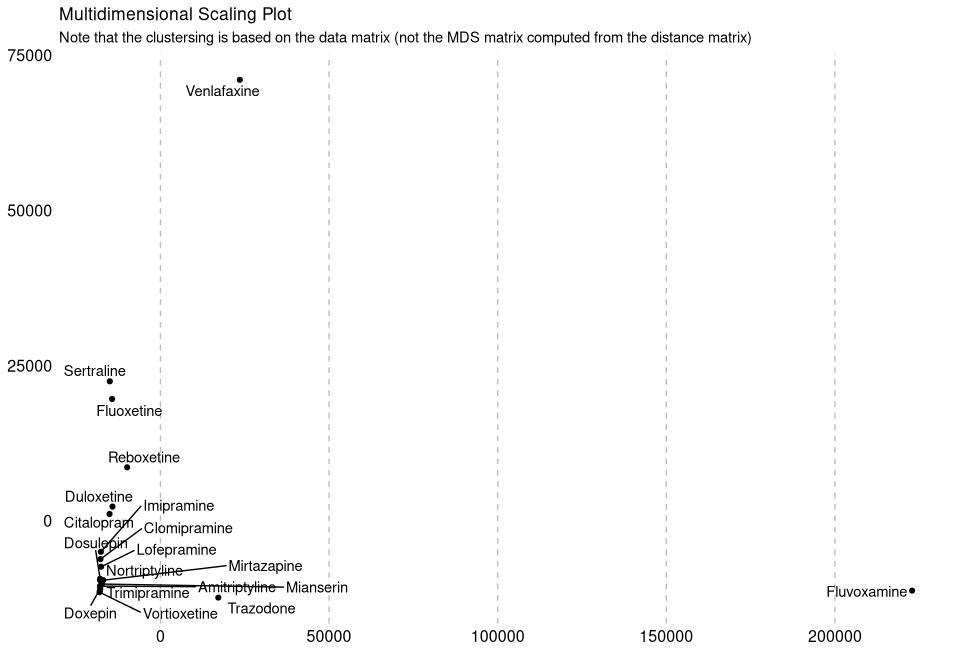

I think a problem this plot reveals is that we cannot simply use Euclidean distance as the dissimilarity measure, otherwise because Venlafaxine and Fluvoxamine are so large in overall magnitude they would be driving the clustering.

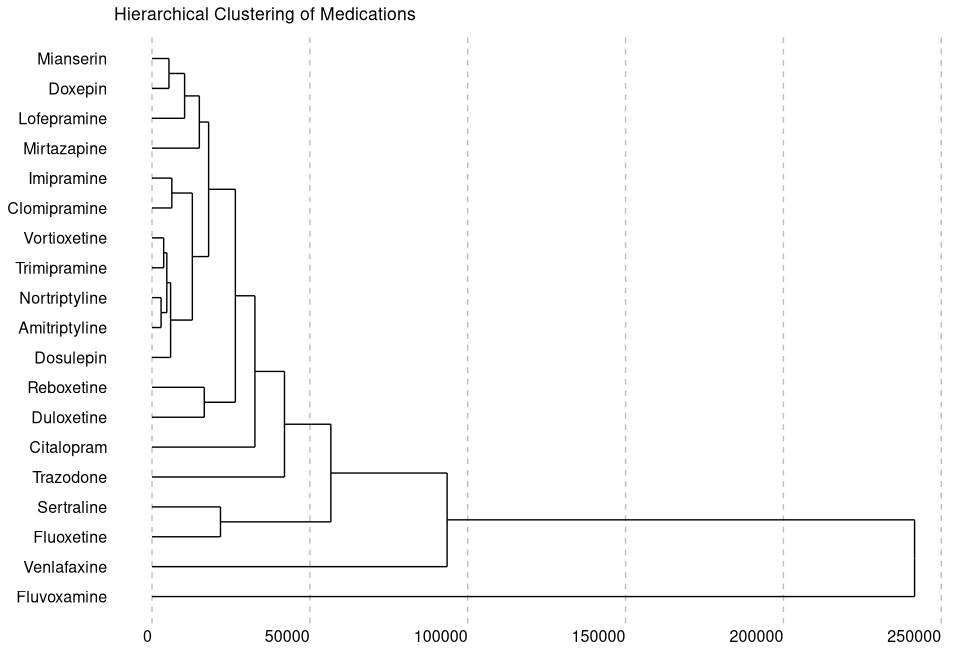

So I think it might be reasonable to instead only consider the “direction” of each observation (i.e. how strong a medication binds to a receptor *relative to other receptors*).

We first use cosine distance for this purpose, which measures the cosine of the angle between two observation vectors (so the magnitude of the vectors do not matter, only direction is considered).

## Hierarchical clustering with cosine distance

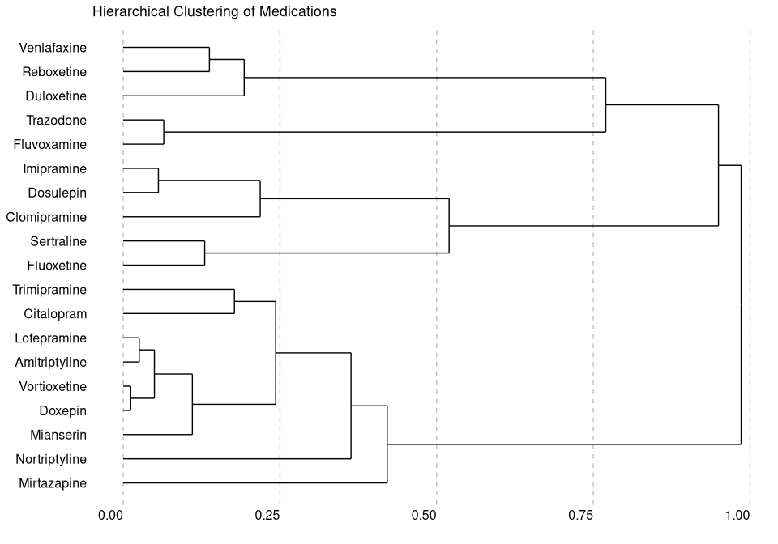

I think using four clusters seems somewhat reasonable.

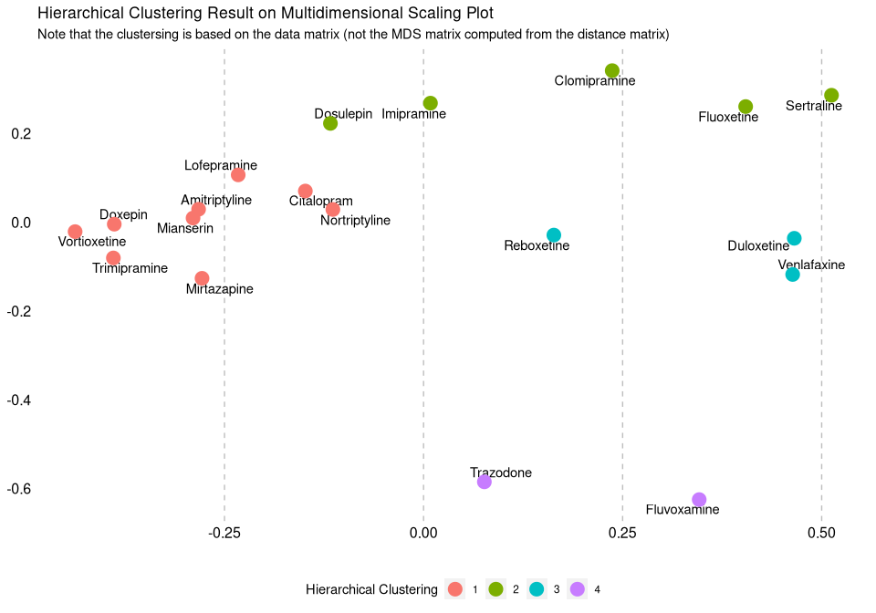

## K-means and hierarchical clustering with normalization

I then divide each observation vector by their norms (i.e. magnitude) so to make them all fall on the circumference of a unit circle before clustering using Euclidean distance (I sort of came up with this myself so the legitamacy of this is a bit questionable. I did do some research and this technique seems to be called “L2 normalization” in machine learning terminologies. “L1” refers to using absolute distance and “L2” Eucledian distance which involves squaring).

There is a derivation that shows [**squred** Eucledian distance on L2 normalized vectors are linearly connected to cosine distance](https://stats.stackexchange.com/questions/299013/cosine-distance-as-similarity-measure-in-kmeans).

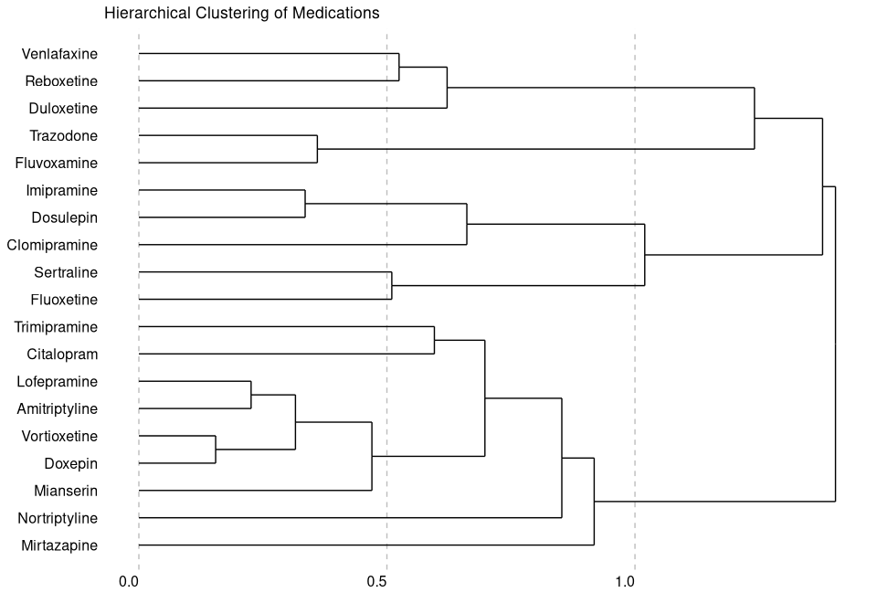

With this normalization we can do some K-means clustering. For some reason I cannot find a package that implements K-means clustering with cosine distance that I can use in a straightforward manner. The `Xmeans` function I was using is one of them but it crashes every time I tried to use cosine distance. It is written in C++ so I can’t do anything about it. I’m suspecting if it is because in one of steps in K-means it requires to relocate the centroids to the center of a cluster, which is implictly minimizing the sum of within-cluster Eucledian distances to the centroids. So using Eucledian distance is the most conventional default.

I tried out different number of Ks ranging from 1 to the number of observations, calculate the within-cluster sums of squres and put them on a scree plot.

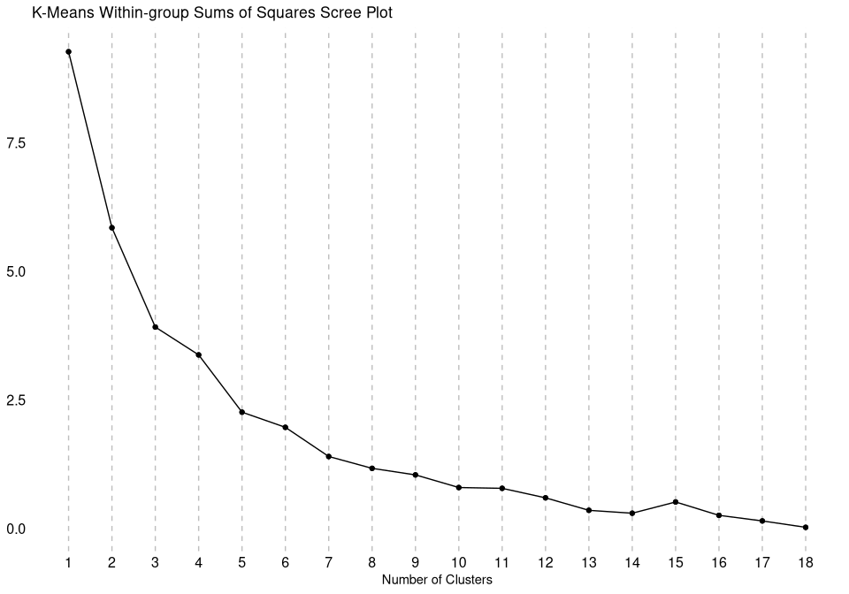

I’m not sure how to interpret this plot - there is no “elbow” to it…

But if we choose four clusters as before the results look similar.

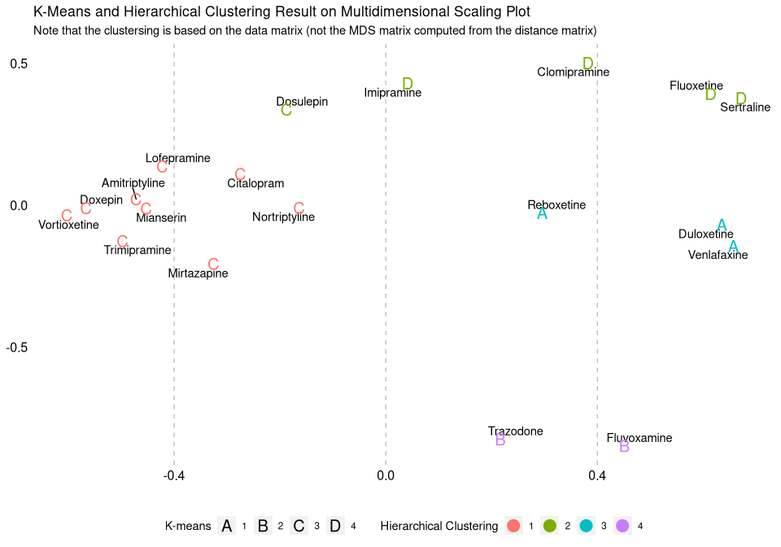

## Hierarchical clustering with inter-individual correlation

Finally I use inter-individual correlation as distance measure. Using inter-individual correlation seems to be a common technique in genetics research but I’m not sure about elsewhere? I saw this being used in our second journal club article “Genes mirror geography within Europe” (Novembre et al. 2008).

There is also a relationship between cosine distance and correlation in that cosine between two standardized variables is equal to correlation. In this paper “How Does Gene Expression Clustering Work?”, the authors actually refer to the measure of cosine as “uncentered correlation” (D’haeseleer 2005).

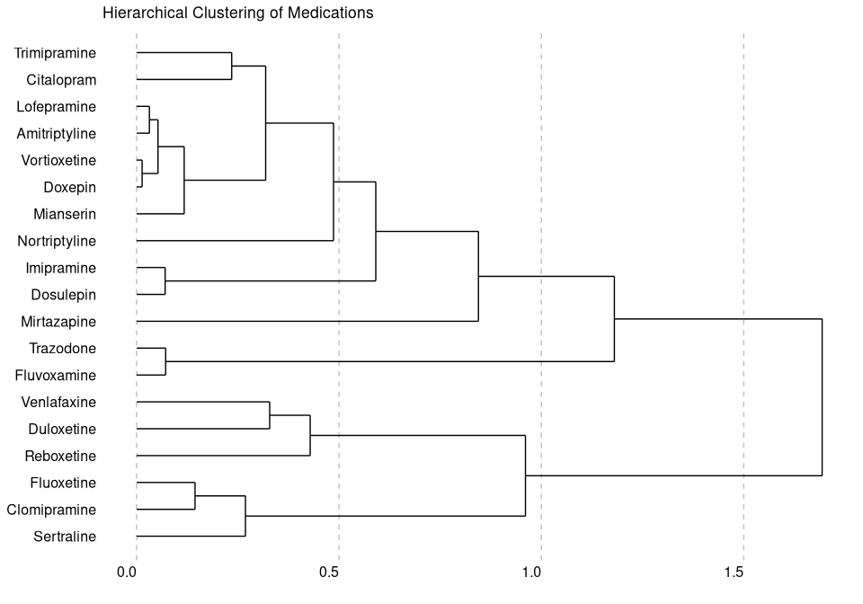

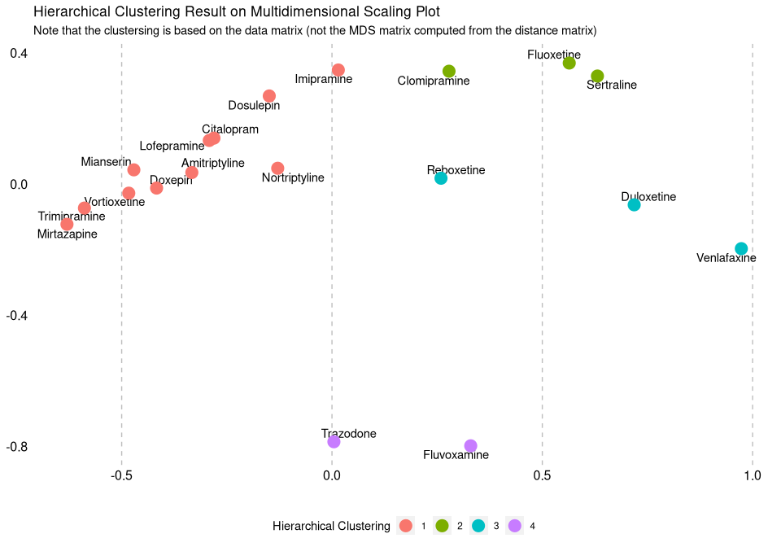

Overall these results all look somewhat similar. I tried a bit to compare it with the table that I pulled from the Argentina paper that you and Gerome didn’t quite like (a list of medication categories can be found in *docs/misc/med_names_cat.txt*). I haven’t been able to make much sense out of it, except the left cluster looks like it’s to do with noradrenergics and the cluster high on the Y-axis seems to be serotonergics.

# Descriptives

**Compare the estimates of PHQ and GAD7 of the subsample that answered the medication questionnaire with the whole GLAD sample.**

PHQ in Sign-up and PHQ in Medication

| Difference | Mean (all) | Mean (subsample) | Statistic | p value | df | CI (low) | CI (high) |
| --- | --- | --- | --- | --- | --- | --- | --- |
| 0 | 12.008 | 12.007 | 0.002 | 0.998 | 9099.815 | -0.184 | 0.184 |

GAD in Sign-up and GAD in Medication

| Difference | Mean (all) | Mean (subsample) | Statistic | p value | df | CI (low) | CI (high) |
| --- | --- | --- | --- | --- | --- | --- | --- |
| 0.371 | 9.56 | 9.189 | 4.602 | <0.01 | 9254.605 | 0.213 | 0.529 |

## Descriptives table

|  | Male Mean | Male Median | Male SD | Male Range | Male N Valid | Female Mean | Female Median | Female SD | Female Range | Female N Valid | Percentage Valid |
| --- | --- | --- | --- | --- | --- | --- | --- | --- | --- | --- | --- |
| Age | 44.86 | 45.00 | 14.24 | 18-90 | 1287 | 38.15 | 36.00 | 14.03 | 18-93 | 5184 | 98% |
| Number of antidepressants taken | 3.23 | 3.00 | 2.34 | 1-16 | 1301 | 3.13 | 3.00 | 2.10 | 1-18 | 5297 | 99% |
| Current anxiety | 8.66 | 7.00 | 6.08 | 0-21 | 1299 | 9.32 | 8.00 | 5.97 | 0-21 | 5276 | 99% |
| Current depression | 11.49 | 11.00 | 7.23 | 0-27 | 1294 | 12.13 | 12.00 | 6.95 | 0-27 | 5271 | 99% |
| Lifetime anxiety | 12.13 | 12.00 | 1.53 | 4-14 | 1035 | 12.40 | 13.00 | 1.36 | 3-14 | 4280 | 80% |
| Lifetime depression | 0.51 | 0.00 | 0.97 | 0-4 | 1164 | 0.54 | 0.00 | 0.99 | 0-4 | 4660 | 88% |
| Personality disorder | 17.16 | 17.00 | 3.69 | 9-34 | 1298 | 17.39 | 17.00 | 3.68 | 9-33 | 5271 | 99% |
| Panic disorder symptoms (N) | 5.79 | 6.00 | 3.67 | 0-13 | 1301 | 6.95 | 7.00 | 3.50 | 0-13 | 5281 | 99% |
| Psychiatric diagnoses (N) | 2.84 | 3.00 | 1.59 | 0-11 | 1300 | 3.28 | 3.00 | 1.86 | 0-14 | 5277 | 99% |
| Relatives with psychitric diagnoses (N) | 3.70 | 3.00 | 4.01 | 0-29 | 664 | 4.42 | 3.00 | 4.66 | 0-30 | 3272 | 59% |
| BMI | 27.59 | 26.95 | 5.64 | 13-59 | 1276 | 28.45 | 27.08 | 7.52 | 13-59 | 5170 | 97% |
| Mean effectiveness | 3.07 | 3.00 | 1.64 | 1-6 | 1258 | 3.22 | 3.00 | 1.62 | 1-6 | 5182 | 97% |
| Mean side effects | 3.20 | 2.33 | 3.35 | 0-23 | 1301 | 3.60 | 2.75 | 3.49 | 0-26 | 5297 | 99% |
| Mean side effects (SE_20) | 2.48 | 1.75 | 2.77 | 0-20 | 1301 | 2.71 | 2.00 | 2.87 | 0-23 | 5297 | 99% |
| Mean side effects (SE_15) | 1.74 | 1.00 | 1.99 | 0-15 | 1301 | 1.87 | 1.20 | 2.07 | 0-18 | 5297 | 99% |
| Mean side effects (SE_10) | 1.10 | 1.00 | 1.25 | 0-10 | 1301 | 1.19 | 1.00 | 1.35 | 0-13 | 5297 | 99% |
| Age at earliest treatment | 31.26 | 29.00 | 12.09 | 9-85 | 1293 | 25.75 | 23.00 | 10.17 | 8-73 | 5266 | 99% |
| Time on Antidepressants | 16.17 | 13.00 | 11.29 | 1-88 | 1299 | 15.63 | 13.00 | 10.28 | 1-100 | 5291 | 99% |
| Likelihood of remission | 2.46 | 3.00 | 0.84 | 1-3 | 1096 | 2.44 | 3.00 | 0.84 | 1-3 | 4705 | 87% |
| Likelihood of intolerance | 1.71 | 1.00 | 0.85 | 1-3 | 1023 | 1.74 | 1.00 | 0.84 | 1-3 | 4320 | 81% |
| Mean improvement duration | 3.70 | 4.00 | 1.47 | 0-5 | 971 | 3.61 | 4.00 | 1.43 | 0-5 | 4141 | 77% |
| Overall Benefits | 4.38 | 5.00 | 1.22 | 2-6 | 1287 | 4.66 | 5.00 | 1.15 | 1-6 | 5230 | 98% |
| Overall side effects | 3.03 | 3.00 | 1.30 | 1-5 | 1290 | 3.01 | 3.00 | 1.24 | 1-6 | 5239 | 98% |
| Number of Best Aspects | 4.14 | 4.00 | 2.09 | 1-8 | 1301 | 4.39 | 4.00 | 2.03 | 1-8 | 5297 | 99% |

Note: (N) indicates that the variable is counts (e.g. number of diagnoses).

## Side effect indices

**Make a plan how to deal with common side effects.**

As I explained in the OSF document we will compute three indices by discarding side effects with prevalence higher than certain percentages and could be confounded by residual or discontinuation-related symptoms or co-morbid physical diseases.

*From docs/dat_clean.md:*

> - We compute three side effect indices, which are the average number of side effects across medications discounting those side effects having higher than respectively 20%, 15% and 10% (*SE_20*, *SE_15* and *SE_10*) prevalence and can be considered as false positives, in that they could be thought of as residual symptoms or discontinuation-related symptoms (descriptions of these can be found in Kelly, Posternak, and Jonathan (2008)), or could be counfounded by co-morbid physical diseases (see Uzun et al. 2009 for descriptions of such side effects).

The originally decided percentages (70%, 60% and 50%) are not plausible, because prevalence of the most common side effects are no more than 30% or so. This figure is consistent with previous research (Kelly, Posternak, and Jonathan 2008).

> The most common side effects reported by patients in the study by Hu et al were drowsiness (38%), dry mouth (34%), and sexual dysfunction (34%).

Here is a plot of side effect prevalence.

The percentages represent the number of instances of a side effect divided by the total number of instances where participants took a medication.

The fill colour indicates the side effects discarded at each percentage level.

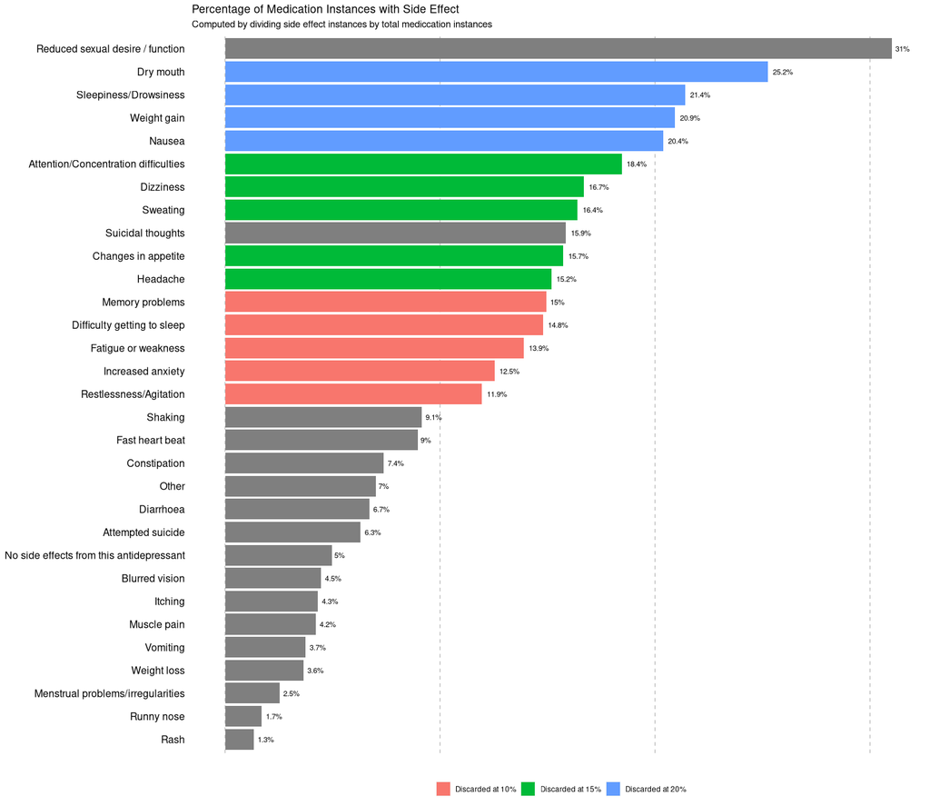

## Side effect prevalence plot

**Plot medication side effect prevalence by medication category.**

We don’t have the category defined from the clustering yet, so I made preliminary plots based on categories from the Argentina paper. These categories are to be found in *docs/misc/med_names_cat.txt*.

The percentages represent the number of instances of a side effect divided by the total number of instances where participants took a medication from a certain category.

A Clopper-Pearson confidence interval (from `binom.test`) was constructed for each percentage. Percentages with an interval wider than 0.4 were discarded. Any zero percentages were also discarded.

Note that this interval is an exact confidence interval rather than the asymptotic interval based on the Z statistic, so should work for small samples. But it can be quite conservative (See [here](https://en.wikipedia.org/wiki/Binomial_proportion_confidence_interval)).

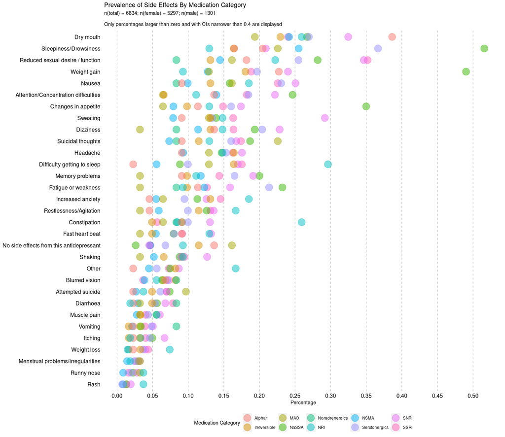

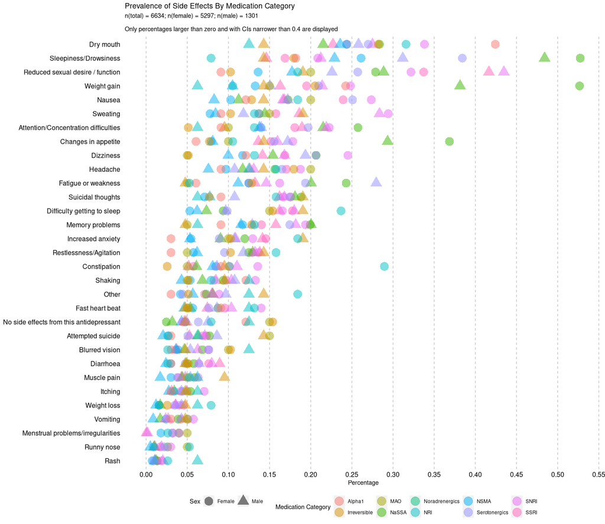

## Processing of treatment response variables

**Think about how to define “treatment response” potentially combination of different variables?**

It would be nice to have one or a few “treatment response” variables defined as the combination of others, because at the moment I’m just including all the individual variables and this means we need to run a dozen of models. I’m thinking of just browsing through all the papers that measure side effects and see if they did something similar. Would this be a good idea and what studies would be a good place to start?

Currently the only processing I’ve done is just averaging and binning some variables.

*From docs/dat_clean.md:*

> Binning was applied to some variables computed by averaging ordinal variables taking only few levels, since as expected such averaging produced variables concentrated at certain values but sparse elsewhere. The number of bins were determined by inspection of the stem-and-leaf plots and histograms and were selected such that the cut-offs are most natural and with a sufficient number of bins to minimize loss of information yet retaining an appropriate number of observations in each bin.

**Before binning:**

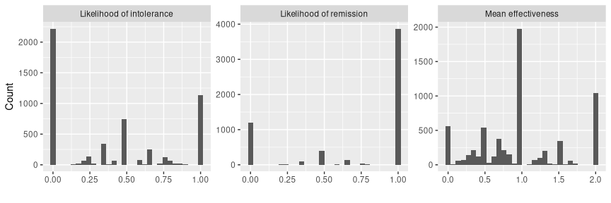

**After binning:**

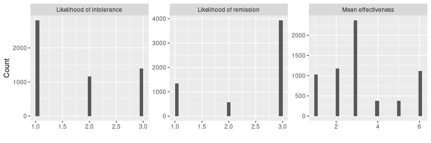

## Histograms of variables

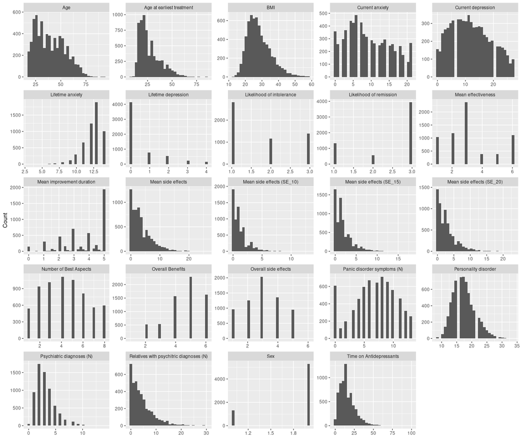

## Visualising correlations

**Add trauma to correlation matrix**

I don’t know why I haven’t done this. I’ve got the scoring algorithm from Christ and looked at it. Will look again.

**Include family history (psychiatric disorders in first-degree relatives) in analysis**

Okay so I’m not sure if what I did was just “first-degree” relatives. Will check again.

**Add recurrent and single-episode lifetime depression to the correlation matrix**

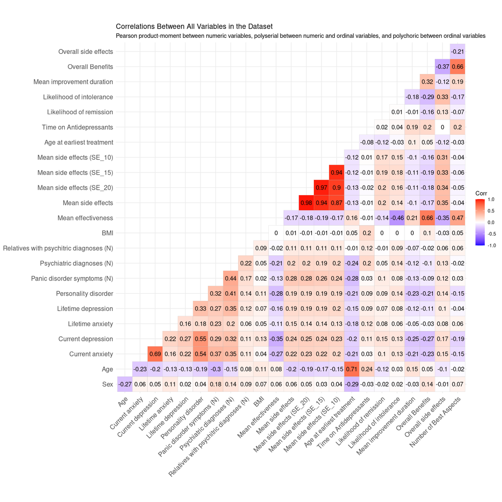

# Analyses

## Confirmatory Analysis 1

For confirmatory analysis 1 we seek to identify correlates of antidepressants side effect severity (See *manuscripts/OSF* for detail).

### Model 1

**Fit univariate regression models with covariates and independent variables.**

The first dependent variables for analysis 1 are:

*From manuscripts/OSF.md:*

> - Side effect severity indices (*SE_20*, *SE_15* and *SE_10*)
>   - We compute three side effect indices, which are the average number of side effects across medications discounting those side effects having higher than respectively 20%, 15% and 10% (*SE_20*, *SE_15* and *SE_10*) prevalence and can be considered as false positives, in that they could be thought of as residual symptoms or discontinuation-related symptoms (descriptions of these can be found in Kelly, Posternak, and Jonathan (2008)), or could be counfounded by co-morbid physical diseases (see Uzun et al. 2009 for descriptions of such side effects).

Below are the coefficients from univariate models where we fit a logistic regression model for $Y = 0$ and a gamma GLM with log link for $Y > 0$. Inferential statistics are given by the Wald test.

|  | Mean side effects (SE_20) (Y = 0) OR (95%CI) | Mean side effects (SE_20) (Y = 0) p | Mean side effects (SE_20) (Y > 0) exp(beta) | Mean side effects (SE_20) (Y > 0) p |
| --- | --- | --- | --- | --- |
| Age at earliest treatment | 0.965 (0.96-0.97) | <0.001 | 1.002 (1.001-1.003) | <0.001 |
| Time on Antidepressants | 1.034 (1.027-1.041) | <0.001 | 1.003 (1.002-1.003) | <0.001 |
| Psychiatric diagnoses (N) | 1.236 (1.189-1.286) | <0.001 | 0.981 (0.978-0.984) | <0.001 |
| Current depression | 1.042 (1.033-1.052) | <0.001 | 0.991 (0.991-0.992) | <0.001 |
| Lifetime anxiety | 1.153 (1.101-1.207) | <0.001 | 0.974 (0.968-0.979) | <0.001 |
| Relatives with psychitric diagnoses (N) | 1.028 (1.01-1.048) | 0.003 | 0.995 (0.994-0.997) | <0.001 |
| Current anxiety | 1.036 (1.026-1.047) | <0.001 | 0.99 (0.989-0.991) | <0.001 |
| Lifetime depression | 1.324 (1.226-1.435) | <0.001 | 0.964 (0.959-0.969) | <0.001 |
| Personality disorder | 1.064 (1.046-1.083) | <0.001 | 0.988 (0.987-0.99) | <0.001 |
| Panic disorder symptoms (N) | 1.097 (1.078-1.115) | <0.001 | 0.979 (0.977-0.981) | <0.001 |
| BMI | 0.994 (0.985-1.002) | 0.14 | 1 (0.999-1.001) | 0.907 |
| Age | 0.974 (0.97-0.979) | <0.001 | 1.003 (1.003-1.004) | <0.001 |
| Sex | 1.207 (1.04-1.396) | 0.012 | 0.985 (0.968-1.003) | 0.11 |

|  | Mean side effects (SE_15) (Y = 0) OR (95%CI) | Mean side effects (SE_15) (Y = 0) p | Mean side effects (SE_15) (Y > 0) exp(beta) | Mean side effects (SE_15) (Y > 0) p |
| --- | --- | --- | --- | --- |
| Age at earliest treatment | 0.967 (0.962-0.972) | <0.001 | 1.002 (1.001-1.003) | <0.001 |
| Time on Antidepressants | 1.035 (1.029-1.042) | <0.001 | 1.004 (1.003-1.005) | <0.001 |
| Psychiatric diagnoses (N) | 1.245 (1.2-1.293) | <0.001 | 0.975 (0.971-0.979) | <0.001 |
| Current depression | 1.044 (1.035-1.053) | <0.001 | 0.988 (0.987-0.99) | <0.001 |
| Lifetime anxiety | 1.146 (1.096-1.197) | <0.001 | 0.964 (0.956-0.972) | <0.001 |
| Relatives with psychitric diagnoses (N) | 1.032 (1.014-1.05) | 0.001 | 0.993 (0.991-0.996) | <0.001 |
| Current anxiety | 1.041 (1.031-1.051) | <0.001 | 0.987 (0.985-0.988) | <0.001 |
| Lifetime depression | 1.345 (1.25-1.452) | <0.001 | 0.95 (0.943-0.958) | <0.001 |
| Personality disorder | 1.069 (1.051-1.087) | <0.001 | 0.984 (0.982-0.986) | <0.001 |
| Panic disorder symptoms (N) | 1.097 (1.08-1.115) | <0.001 | 0.973 (0.97-0.976) | <0.001 |
| BMI | 0.996 (0.988-1.004) | 0.358 | 1 (0.999-1.002) | 0.728 |
| Age | 0.979 (0.975-0.983) | <0.001 | 1.004 (1.003-1.005) | <0.001 |
| Sex | 1.158 (1.005-1.332) | 0.042 | 0.986 (0.961-1.011) | 0.288 |

|  | Mean side effects (SE_10) (Y = 0) OR (95%CI) | Mean side effects (SE_10) (Y = 0) p | Mean side effects (SE_10) (Y > 0) exp(beta) | Mean side effects (SE_10) (Y > 0) p |
| --- | --- | --- | --- | --- |
| Age at earliest treatment | 0.97 (0.966-0.975) | <0.001 | 1.003 (1.001-1.004) | <0.001 |
| Time on Antidepressants | 1.042 (1.036-1.049) | <0.001 | 1.005 (1.004-1.007) | <0.001 |
| Psychiatric diagnoses (N) | 1.235 (1.194-1.279) | <0.001 | 0.964 (0.958-0.97) | <0.001 |
| Current depression | 1.043 (1.035-1.052) | <0.001 | 0.985 (0.983-0.987) | <0.001 |
| Lifetime anxiety | 1.138 (1.091-1.187) | <0.001 | 0.949 (0.937-0.961) | <0.001 |
| Relatives with psychitric diagnoses (N) | 1.029 (1.012-1.046) | 0.001 | 0.99 (0.987-0.994) | <0.001 |
| Current anxiety | 1.038 (1.028-1.048) | <0.001 | 0.983 (0.981-0.986) | <0.001 |
| Lifetime depression | 1.361 (1.271-1.461) | <0.001 | 0.929 (0.919-0.94) | <0.001 |
| Personality disorder | 1.07 (1.054-1.087) | <0.001 | 0.978 (0.975-0.981) | <0.001 |
| Panic disorder symptoms (N) | 1.09 (1.074-1.107) | <0.001 | 0.965 (0.961-0.969) | <0.001 |
| BMI | 0.999 (0.992-1.007) | 0.847 | 1.001 (0.999-1.003) | 0.519 |
| Age | 0.984 (0.98-0.987) | <0.001 | 1.005 (1.004-1.007) | <0.001 |
| Sex | 1.067 (0.931-1.22) | 0.349 | 0.962 (0.926-0.999) | 0.044 |

**Below are the multivariate models**. I looked at the diagnostics for these multivariate models and they all seem to fit quite well with regards to residual distributions. There seems to be, however, some multicollinearity going on with those anxiety and depression related variables.

|  | Mean side effects (SE_20) (Y = 0) OR (95%CI) | Mean side effects (SE_20) (Y = 0) p | Mean side effects (SE_20) (Y > 0) exp(beta) | Mean side effects (SE_20) (Y > 0) p |
| --- | --- | --- | --- | --- |
| Age at earliest treatment | 0.998 (0.985-1.011) | 0.724 | 0.996 (0.995-0.998) | <0.001 |
| Time on Antidepressants | 1.039 (1.026-1.052) | <0.001 | 1.002 (1-1.003) | 0.010 |
| Psychiatric diagnoses (N) | 1.159 (1.076-1.25) | <0.001 | 1 (0.995-1.005) | 0.956 |
| Current depression | 1.023 (1.003-1.045) | 0.027 | 0.997 (0.995-0.999) | 0.003 |
| Lifetime anxiety | 1.015 (0.949-1.084) | 0.662 | 0.99 (0.982-0.997) | 0.009 |
| Relatives with psychitric diagnoses (N) | 1.019 (0.994-1.045) | 0.143 | 0.997 (0.996-0.999) | 0.003 |
| Current anxiety | 0.994 (0.97-1.018) | 0.613 | 0.999 (0.996-1.001) | 0.265 |
| Lifetime depression | 1.188 (1.049-1.353) | 0.008 | 0.992 (0.984-1.001) | 0.086 |
| Personality disorder | 0.964 (0.93-0.999) | 0.045 | 0.998 (0.995-1.001) | 0.308 |
| Panic disorder symptoms (N) | 1.032 (0.999-1.066) | 0.054 | 0.984 (0.981-0.988) | <0.001 |
| BMI | 0.981 (0.967-0.995) | 0.009 | 1 (0.999-1.002) | 0.563 |
| Age | 0.975 (0.965-0.985) | <0.001 | 1.003 (1.002-1.004) | <0.001 |
| Sex | 1.01 (0.78-1.301) | 0.937 | 1.017 (0.99-1.044) | 0.209 |

|  | Mean side effects (SE_15) (Y = 0) OR (95%CI) | Mean side effects (SE_15) (Y = 0) p | Mean side effects (SE_15) (Y > 0) exp(beta) | Mean side effects (SE_15) (Y > 0) p |
| --- | --- | --- | --- | --- |
| Age at earliest treatment | 0.994 (0.982-1.007) | 0.353 | 0.996 (0.993-0.998) | <0.001 |
| Time on Antidepressants | 1.039 (1.027-1.052) | <0.001 | 1.002 (1.001-1.004) | 0.007 |
| Psychiatric diagnoses (N) | 1.144 (1.067-1.229) | <0.001 | 1 (0.993-1.007) | 0.918 |
| Current depression | 1.024 (1.004-1.044) | 0.019 | 0.996 (0.993-0.999) | 0.007 |
| Lifetime anxiety | 1.003 (0.941-1.07) | 0.916 | 0.987 (0.975-0.998) | 0.020 |
| Relatives with psychitric diagnoses (N) | 1.018 (0.994-1.042) | 0.141 | 0.996 (0.994-0.999) | 0.003 |
| Current anxiety | 1.001 (0.978-1.025) | 0.917 | 0.999 (0.995-1.002) | 0.377 |
| Lifetime depression | 1.212 (1.077-1.371) | 0.002 | 0.989 (0.977-1.001) | 0.079 |
| Personality disorder | 0.97 (0.937-1.004) | 0.079 | 0.996 (0.992-1.001) | 0.083 |
| Panic disorder symptoms (N) | 1.029 (0.998-1.061) | 0.069 | 0.979 (0.975-0.984) | <0.001 |
| BMI | 0.981 (0.968-0.995) | 0.006 | 1.001 (0.999-1.003) | 0.438 |
| Age | 0.98 (0.97-0.99) | <0.001 | 1.003 (1.002-1.005) | <0.001 |
| Sex | 1.046 (0.817-1.334) | 0.718 | 1.023 (0.983-1.062) | 0.253 |

|  | Mean side effects (SE_10) (Y = 0) OR (95%CI) | Mean side effects (SE_10) (Y = 0) p | Mean side effects (SE_10) (Y > 0) exp(beta) | Mean side effects (SE_10) (Y > 0) p |
| --- | --- | --- | --- | --- |
| Age at earliest treatment | 0.993 (0.98-1.005) | 0.228 | 0.994 (0.991-0.997) | <0.001 |
| Time on Antidepressants | 1.043 (1.032-1.055) | <0.001 | 1.004 (1.001-1.006) | 0.002 |
| Psychiatric diagnoses (N) | 1.133 (1.061-1.211) | <0.001 | 1.001 (0.99-1.012) | 0.905 |
| Current depression | 1.02 (1.002-1.04) | 0.034 | 0.995 (0.991-0.999) | 0.016 |
| Lifetime anxiety | 1.015 (0.954-1.079) | 0.647 | 0.978 (0.962-0.995) | 0.011 |
| Relatives with psychitric diagnoses (N) | 1.017 (0.995-1.04) | 0.136 | 0.995 (0.991-0.999) | 0.005 |
| Current anxiety | 0.992 (0.971-1.015) | 0.506 | 0.998 (0.993-1.003) | 0.446 |
| Lifetime depression | 1.219 (1.091-1.368) | 0.001 | 0.979 (0.962-0.997) | 0.024 |
| Personality disorder | 0.981 (0.95-1.014) | 0.251 | 0.991 (0.985-0.998) | 0.008 |
| Panic disorder symptoms (N) | 1.033 (1.003-1.064) | 0.031 | 0.976 (0.969-0.983) | <0.001 |
| BMI | 0.984 (0.971-0.997) | 0.014 | 1.001 (0.998-1.004) | 0.525 |
| Age | 0.984 (0.974-0.994) | 0.001 | 1.004 (1.002-1.007) | 0.003 |
| Sex | 0.926 (0.728-1.174) | 0.531 | 0.983 (0.924-1.043) | 0.574 |

It’s interesting though this paper “Modelling Non-negative Data with Clumping at Zero: A Survey” (Y and A 2002) suggests that it is also plausible to apply binning to data whilst treating zeroes as an independent category and fit proportional odds models (which I’m using below not for continuous but for categorical data).

The following two dependent variables in analysis 1 are ordinal variables for which I used a partial proportional odds model. The formulation the model is given by

$$logit(P(Y_{i} \leq j)) = \sum{x_i \beta} + \sum{z_i \beta_j} + \theta_j$$

Suppose that $Y_i = j (j = 1, 2, 3, ...J)$, this amounts to fitting $J - 1$ logistic regression models ($logit(P_i \leq 1)$, $logit(P_i \leq 2)$, …, $logit(P_i \leq J - 1)$. $x$s are a set of predictors with constant effect $\beta$s in all the logistic models and $z$s a set of predictors with different effects $\beta_j$s across the models (i.e. across different levels of the response variable). $\theta_j$ is the intercept for each model which also differs by level.

The constant $\beta$s are termed **ordinal effects**. $\beta_j$s, which are free to vary depending on the level of $Y$ are termed **nominal effects**.

The package implements a likelihood ratio test for whether an effect is ordinal, by comparing the models where the effect is specified to be ordinal or nominal. I first entered all variables as ordinal, ran the test and re-entered the significant variables as nominal effects.

**Fit univariate regression models with covariates and independent variables.**

I cannot run univariate regressions with the package I’m using for this model, because it does not allow specifying only nominal effects - perhaps the package author thinks that with only nominal effects the model isn’t “ordinal” any more in a sense that the direction of the effect might not stay the same across levels? It’s likely that there are other packages that can do this though. Would this be necessary to do?

### Model 2

The second dependent variable for analysis 1 is:

*From manuscripts/OSF.md:*

> - Self-report side effect severity rating (1-5 Likert scale)

>   Item in questionnaire: *“Overall, how would you rate the side-effects of taking antidepressants?”*

| Overall side effects | Lower than or equal to 1 (vs. higher than 1 ) OR (95%CI) | Lower than or equal to 1 (vs. higher than 1 ) p | Lower than or equal to 2 (vs. higher than 2 ) OR (95%CI) | Lower than or equal to 2 (vs. higher than 2 ) p | Lower than or equal to 3 (vs. higher than 3 ) OR (95%CI) | Lower than or equal to 3 (vs. higher than 3 ) p | Lower than or equal to 4 (vs. higher than 4 ) OR (95%CI) | Lower than or equal to 4 (vs. higher than 4 ) p |
| --- | --- | --- | --- | --- | --- | --- | --- | --- |
| **Nominal Effects** |  |  |  |  |  |  |  |  |
| Age at earliest treatment | 1.005 (0.991-1.02) | 0.478 | 1.007 (0.995-1.019) | 0.245 | 1.013 (1.001-1.025) | 0.034 | 1.019 (1.005-1.034) | 0.010 |
| Time on Antidepressants | 0.972 (0.959-0.985) | <0.001 | 0.995 (0.985-1.004) | 0.288 | 1.013 (1.004-1.022) | 0.006 | 1.039 (1.026-1.052) | <0.001 |
| Psychiatric diagnoses (N) | 0.929 (0.862-1.001) | 0.053 | 0.944 (0.894-0.998) | 0.042 | 0.965 (0.917-1.016) | 0.172 | 0.943 (0.889-1.002) | 0.056 |
| Age | 1.012 (1.001-1.023) | 0.035 | 1.003 (0.994-1.012) | 0.54 | 0.994 (0.985-1.003) | 0.218 | 0.973 (0.962-0.983) | <0.001 |
| **Ordinal Effects** |  |  |  |  |  |  |  |  |
| Current depression | 1.02 (1.006-1.035) | 0.006 |  |  |  |  |  |  |
| Lifetime anxiety | 1.025 (0.975-1.078) | 0.337 |  |  |  |  |  |  |
| Relatives with psychitric diagnoses (N) | 1.018 (1.002-1.034) | 0.027 |  |  |  |  |  |  |
| Current anxiety | 1.007 (0.99-1.024) | 0.431 |  |  |  |  |  |  |
| Lifetime depression | 1.02 (0.945-1.101) | 0.606 |  |  |  |  |  |  |
| Personality disorder | 1.019 (0.995-1.044) | 0.125 |  |  |  |  |  |  |
| Panic disorder symptoms (N) | 1.019 (0.996-1.043) | 0.103 |  |  |  |  |  |  |
| BMI | 0.986 (0.976-0.996) | 0.005 |  |  |  |  |  |  |
| Sex | 0.926 (0.768-1.118) | 0.425 |  |  |  |  |  |  |

### Model 3

The third dependent variable for analysis 1 is:

*From manuscripts/OSF.md:*

> - Likelihood of intolerance
>   - Computed by averaging treatment intolerance (binary) across medications.

The measure originally collected in the questionnaire is:

> - Treatment intolerance for each antidepressant (binary)

>   Example item in questionnaire: *“Did you have to stop taking any of these medication(s) because of side effects? - Citalopram (e.g. Cipramil)”*

| Likelihood of intolerance | Lower than or equal to 1 (vs. higher than 1 ) OR (95%CI) | Lower than or equal to 1 (vs. higher than 1 ) p | Lower than or equal to 2 (vs. higher than 2 ) OR (95%CI) | Lower than or equal to 2 (vs. higher than 2 ) p |
| --- | --- | --- | --- | --- |
| **Nominal Effects** |  |  |  |  |
| Time on Antidepressants | 1.001 (0.991-1.01) | 0.881 | 1.013 (1.002-1.024) | 0.017 |
| **Ordinal Effects** |  |  |  |  |
| Age at earliest treatment | 0.989 (0.977-1.001) | 0.082 |  |  |
| Psychiatric diagnoses (N) | 1.067 (1.013-1.125) | 0.015 |  |  |
| Current depression | 1.013 (0.996-1.03) | 0.131 |  |  |
| Lifetime anxiety | 1.041 (0.978-1.108) | 0.203 |  |  |
| Relatives with psychitric diagnoses (N) | 1.023 (1.004-1.041) | 0.015 |  |  |
| Current anxiety | 1.02 (1-1.041) | 0.052 |  |  |
| Lifetime depression | 1.055 (0.969-1.149) | 0.216 |  |  |
| Personality disorder | 1.022 (0.994-1.052) | 0.128 |  |  |
| Panic disorder symptoms (N) | 0.991 (0.964-1.019) | 0.539 |  |  |
| BMI | 0.984 (0.973-0.995) | 0.005 |  |  |
| Age | 1.019 (1.009-1.029) | <0.001 |  |  |
| Sex | 1.16 (0.922-1.459) | 0.206 |  |  |

## Confirmatory Analysis 2

For confirmatory analysi 2 we seek to determine if effectiveness is assocaited with side effect severities.

### Model 1

The first dependent variable for confirmatory analysis 2 is the average effectiveness index.

*From manuscripts/OSF.md:*

> - Average effectiveness index
>   - Computed by averaging self-report effectiveness rating (0-2 Likert scale) across medications.

*From docs/dat_clean.md:*

> As this variable is computed from several (the number depends on how many medications a participant has taken in life time, which is unlikely to be very high) variables having only three levels, we anticipated the values of this variable to be dense at 1 and 0.5 intervals but sparse elsewhere. Therefore, it would be more reasonable to bin this variable at 0.5 cut-offs, recoding it into an ordinal variable of six levels.

| Mean effectiveness | Lower than or equal to 1 (vs. higher than 1 ) OR (95%CI) | Lower than or equal to 1 (vs. higher than 1 ) p | Lower than or equal to 2 (vs. higher than 2 ) OR (95%CI) | Lower than or equal to 2 (vs. higher than 2 ) p | Lower than or equal to 3 (vs. higher than 3 ) OR (95%CI) | Lower than or equal to 3 (vs. higher than 3 ) p | Lower than or equal to 4 (vs. higher than 4 ) OR (95%CI) | Lower than or equal to 4 (vs. higher than 4 ) p | Lower than or equal to 5 (vs. higher than 5 ) OR (95%CI) | Lower than or equal to 5 (vs. higher than 5 ) p |
| --- | --- | --- | --- | --- | --- | --- | --- | --- | --- | --- |
| **Nominal Effects** |  |  |  |  |  |  |  |  |  |  |
| Age at earliest treatment | 0.993 (0.978-1.008) | 0.368 | 0.981 (0.97-0.992) | 0.001 | 0.979 (0.968-0.99) | <0.001 | 0.951 (0.939-0.963) | <0.001 | 0.934 (0.92-0.948) | <0.001 |
| Psychiatric diagnoses (N) | 1.028 (0.965-1.095) | 0.389 | 1.074 (1.019-1.132) | 0.008 | 1.032 (0.972-1.095) | 0.306 | 1.037 (0.972-1.106) | 0.275 | 1.081 (1.003-1.165) | 0.042 |
| Current depression | 1.042 (1.021-1.064) | <0.001 | 1.059 (1.041-1.077) | <0.001 | 1.062 (1.042-1.081) | <0.001 | 1.072 (1.051-1.095) | <0.001 | 1.083 (1.057-1.109) | <0.001 |
| Current anxiety | 1.018 (0.994-1.043) | 0.148 | 1.002 (0.983-1.022) | 0.823 | 1.01 (0.989-1.033) | 0.35 | 1.012 (0.989-1.036) | 0.305 | 1.001 (0.975-1.028) | 0.928 |
| BMI | 0.964 (0.95-0.98) | <0.001 | 0.976 (0.965-0.988) | <0.001 | 0.984 (0.971-0.996) | 0.010 | 0.989 (0.975-1.003) | 0.126 | 0.994 (0.979-1.01) | 0.493 |
| Age | 1.003 (0.991-1.015) | 0.643 | 1.012 (1.003-1.021) | 0.007 | 1.005 (0.995-1.014) | 0.331 | 1.03 (1.019-1.041) | <0.001 | 1.047 (1.034-1.06) | <0.001 |
| **Ordinal Effects** |  |  |  |  |  |  |  |  |  |  |
| Mean side effects (SE_20) | 0.918 (0.894-0.942) | <0.001 |  |  |  |  |  |  |  |  |
| Lifetime depression | 0.94 (0.871-1.016) | 0.119 |  |  |  |  |  |  |  |  |
| Personality disorder | 0.955 (0.932-0.979) | <0.001 |  |  |  |  |  |  |  |  |
| Panic disorder symptoms (N) | 1.029 (1.005-1.054) | 0.017 |  |  |  |  |  |  |  |  |
| Relatives with psychitric diagnoses (N) | 1.011 (0.995-1.028) | 0.179 |  |  |  |  |  |  |  |  |
| Sex | 1.377 (1.135-1.671) | 0.001 |  |  |  |  |  |  |  |  |

### Model 2

> - Self-report overall benefit of taking antidepressants (1-5 Likert scale)

>   Item in questionnaire: *“Overall, how would you rate the benefits of taking antidepressants?”*

| Overall Benefits | Lower than or equal to 0 (vs. higher than 0 ) OR (95%CI) | Lower than or equal to 0 (vs. higher than 0 ) p | Lower than or equal to 1 (vs. higher than 1 ) OR (95%CI) | Lower than or equal to 1 (vs. higher than 1 ) p | Lower than or equal to 2 (vs. higher than 2 ) OR (95%CI) | Lower than or equal to 2 (vs. higher than 2 ) p | Lower than or equal to 3 (vs. higher than 3 ) OR (95%CI) | Lower than or equal to 3 (vs. higher than 3 ) p | Lower than or equal to 4 (vs. higher than 4 ) OR (95%CI) | Lower than or equal to 4 (vs. higher than 4 ) p |
| --- | --- | --- | --- | --- | --- | --- | --- | --- | --- | --- |
| **Nominal Effects** |  |  |  |  |  |  |  |  |  |  |
| Age at earliest treatment | 0.743 (0.434-1.27) | 0.277 | 0.947 (0.929-0.966) | <0.001 | 0.966 (0.952-0.98) | <0.001 | 0.975 (0.964-0.987) | <0.001 | 0.983 (0.971-0.996) | 0.012 |
| Time on Antidepressants | 0.976 (0.749-1.272) | 0.858 | 0.88 (0.863-0.898) | <0.001 | 0.91 (0.897-0.924) | <0.001 | 0.944 (0.935-0.954) | <0.001 | 0.971 (0.961-0.981) | <0.001 |
| Age | 1.02 (0.785-1.326) | 0.881 | 1.055 (1.04-1.07) | <0.001 | 1.044 (1.032-1.055) | <0.001 | 1.029 (1.019-1.038) | <0.001 | 1.009 (0.999-1.019) | 0.091 |
| **Ordinal Effects** |  |  |  |  |  |  |  |  |  |  |
| Mean side effects (SE_20) | 0.916 (0.893-0.94) | <0.001 |  |  |  |  |  |  |  |  |
| Psychiatric diagnoses (N) | 0.968 (0.923-1.015) | 0.179 |  |  |  |  |  |  |  |  |
| Current depression | 0.949 (0.935-0.963) | <0.001 |  |  |  |  |  |  |  |  |
| Lifetime anxiety | 0.986 (0.938-1.037) | 0.587 |  |  |  |  |  |  |  |  |
| Current anxiety | 0.992 (0.975-1.009) | 0.341 |  |  |  |  |  |  |  |  |
| Lifetime depression | 0.933 (0.863-1.01) | 0.086 |  |  |  |  |  |  |  |  |
| Personality disorder | 0.956 (0.932-0.98) | <0.001 |  |  |  |  |  |  |  |  |
| Panic disorder symptoms (N) | 1.023 (0.999-1.047) | 0.066 |  |  |  |  |  |  |  |  |
| Relatives with psychitric diagnoses (N) | 1.005 (0.989-1.021) | 0.556 |  |  |  |  |  |  |  |  |
| Sex | 1.586 (1.31-1.921) | <0.001 |  |  |  |  |  |  |  |  |

### Model 3

*From manuscripts/OSF.md:*

> - Likelihood of remission
>   - Computed by averaging remission (binary)) across medications.

Original measure from questionnaire:

> - Remission for each antidepressant (binary)

>   Example item in questionnaire: *“After taking Citalopram (e.g. Cipramil) for a period of time, did you ever experience any further symptoms associated with the condition for which you were prescribed antidepressants?”*

*From docs/dat_clean.md:*

> This variable was cut into three bins.

| Likelihood of remission | Lower than or equal to 1 (vs. higher than 1 ) OR (95%CI) | Lower than or equal to 1 (vs. higher than 1 ) p | Lower than or equal to 2 (vs. higher than 2 ) OR (95%CI) | Lower than or equal to 2 (vs. higher than 2 ) p |
| --- | --- | --- | --- | --- |
| **Nominal Effects** |  |  |  |  |
| Psychiatric diagnoses (N) | 1.012 (0.948-1.08) | 0.726 | 1.058 (0.997-1.124) | 0.064 |
| **Ordinal Effects** |  |  |  |  |
| Mean side effects (SE_20) | 1.183 (1.135-1.232) | <0.001 |  |  |
| Age at earliest treatment | 0.995 (0.984-1.006) | 0.381 |  |  |
| Current depression | 1.029 (1.011-1.048) | 0.002 |  |  |
| Lifetime anxiety | 1.011 (0.95-1.075) | 0.739 |  |  |
| Current anxiety | 0.986 (0.965-1.007) | 0.181 |  |  |
| Lifetime depression | 1.05 (0.952-1.159) | 0.331 |  |  |
| Personality disorder | 0.996 (0.965-1.027) | 0.792 |  |  |
| Panic disorder symptoms (N) | 1.013 (0.984-1.043) | 0.382 |  |  |
| Relatives with psychitric diagnoses (N) | 0.996 (0.976-1.016) | 0.674 |  |  |
| BMI | 0.996 (0.984-1.008) | 0.54 |  |  |
| Age | 0.994 (0.986-1.003) | 0.207 |  |  |
| Sex | 0.859 (0.675-1.094) | 0.218 |  |  |

I only included the models that you saw last time and those that I think we will most likely run in the end. There are more models I proposed in the OSF, but since we have not decided on a multiple testing procedure yet I’m not sure if I should run them now. The functions for them are written so once we have the right variables running them should be instantaneous.

# References

D’haeseleer, Patrik. 2005. “How Does Gene Expression Clustering Work?” *Nature Biotechnology* 23 (12): 1499–1501. https://doi.org/10.1038/nbt1205-1499.

Jin, Shaobo, and Fan Yang-Wallentin. 2017. “Asymptotic Robustness Study of the Polychoric Correlation Estimation.” *Psychometrika* 82 (1): 67–85. https://doi.org/10.1007/s11336-016-9512-2.

Kelly, Karen, Michael Posternak, and E. Alpert Jonathan. 2008. “Toward Achieving Optimal Response: Understanding and Managing Antidepressant Side Effects.” *Dialogues in Clinical Neuroscience* 10 (4): 409–18. https://www.ncbi.nlm.nih.gov/pmc/articles/PMC3181894/.

Novembre, John, Toby Johnson, Katarzyna Bryc, Zoltán Kutalik, Adam R. Boyko, Adam Auton, Amit Indap, et al. 2008. “Genes Mirror Geography Within Europe.” *Nature* 456 (7218): 98–101. https://doi.org/10.1038/nature07331.

Uzun, Suzana, Oliver Kozumplik, Radmila Topic, and Miro Jakovljevic. 2009. “Depressive Disorders and Comorbidity: Somatic Illness Vs. side Effect.” *Psychiatria Danubina* 21 (September): 391–8.

Y, Min, and Agresti A. 2002. “MODELING NONNEGATIVE DATA WITH CLUMPING AT ZERO: A SURVEY” 1 (12): 7–33. https://www.sid.ir/en/journal/ViewPaper.aspx?ID=34499.